# Employee-Retention

Fangqi Ouyang

5/25/2019

```r
set.seed(2019)
```

# Load Libraries

```r
library(ggplot2)
library(dplyr)
library(plyr)
library(reshape2)
library(tidyverse)
library(ggpubr)
library(lubridate)
library(class)
library(FNN)
library(ggcorrplot)
library(randomForest)
library(ROCR)
library(dummies)
```

# Data Load and preparation

```r
data <- read.csv("employee_retention.csv")
data <- data[,2:dim(data)[2]]
dim(data)
```

```
[1] 34702     7
```

```r
head(data)
```

```
  employee_id company_id            dept seniority salary  join_date  quit_date
1     1001444          8 temp_contractor         0   5850 2008-01-26 2008-04-25
2      388804          8          design        21 191000 05.17.2011 2012-03-16
3      407990          3          design         9  90000 2012-03-26 2015-04-10
4      120657          2        engineer        20 298000 2013-04-08 2015-01-30
5     1006393          1 temp_contractor         0   8509 2008-07-20 2008-10-18
6      287530          5       marketing        20 180000 2014-06-30
```

There are 34702 observations with 7 variables.

```r
#Calculate the tenure
data$quit_date = as.Date(as.character(data$quit_date),format="%Y-%m-%d")
data$join_date  = as.Date(as.character(data$join_date),format="%Y-%m-%d")
data$tenure =round(as.numeric(data$quit_date-data$join_date)/365,2)
data$week = week(as.Date(data$quit_date,format="%Y-%m-%d"))
```

```r
#Impute the quit result(0 or 1)
last_day = sapply("2015-12-13",FUN = as.Date,format="%Y-%m-%d")
data$quit = ifelse(data$`quit_date`>last_day|is.na(data$`quit_date`),0,1)
```

```r
#The first 6 rows of the data
head(data)
```

```
  employee_id company_id            dept seniority salary  join_date  quit_date
1     1001444          8 temp_contractor         0   5850 2008-01-26 2008-04-25
2      388804          8          design        21 191000       <NA> 2012-03-16
3      407990          3          design         9  90000 2012-03-26 2015-04-10
4      120657          2        engineer        20 298000 2013-04-08 2015-01-30
5     1006393          1 temp_contractor         0   8509 2008-07-20 2008-10-18
6      287530          5       marketing        20 180000 2014-06-30       <NA>
  tenure week quit
1   0.25   17    1
2     NA   11    1
3   3.04   15    1
4   1.81    5    1
5   0.25   42    1
6     NA   NA    0
```

```r
#summary statistics of data
summary(data)
```

```
  employee_id        company_id                   dept         seniority
 Min.   :     36   Min.   : 1.000   customer_service: 9180   Min.   : 0.00
 1st Qu.: 352923   1st Qu.: 1.000   data_science    : 3190   1st Qu.: 0.00
 Median : 706323   Median : 3.000   design          : 1380   Median : 8.00
 Mean   : 646667   Mean   : 4.023   engineer        : 4613   Mean   :10.06
 3rd Qu.:1001324   3rd Qu.: 6.000   marketing       : 3167   3rd Qu.:18.00
 Max.   :1009999   Max.   :12.000   sales           : 3172   Max.   :99.00
                                    temp_contractor :10000
     salary         join_date            quit_date              tenure
 Min.   :  5000   Min.   :2007-01-01   Min.   :2007-04-01   Min.   :0.250
 1st Qu.:  9302   1st Qu.:2009-09-18   1st Qu.:2009-08-01   1st Qu.:0.250
 Median : 88000   Median :2012-01-30   Median :2012-12-21   Median :0.250
 Mean   :100281   Mean   :2011-11-02   Mean   :2012-02-29   Mean   :0.946
 3rd Qu.:158000   3rd Qu.:2013-12-31   3rd Qu.:2014-09-12   3rd Qu.:1.140
 Max.   :408000   Max.   :2015-12-10   Max.   :2015-12-09   Max.   :4.730
 NA's   :239      NA's   :7438         NA's   :11192        NA's   :15265
      week            quit
 Min.   : 1.00   Min.   :0.0000
 1st Qu.:14.00   1st Qu.:0.0000
 Median :27.00   Median :1.0000
 Mean   :26.66   Mean   :0.6775
 3rd Qu.:40.00   3rd Qu.:1.0000
 Max.   :53.00   Max.   :1.0000
 NA's   :11192
```

There are 239 NAs in “salary”, 7438 NAs in “join_date”, 11192 in “quit_date”, 15265 NAs in “tenure” and 11192 NAs in “week”;

```r
#Define the useful function for headcount
headcount <- function(id){
  df <- data[data$company_id==id&!is.na(data$join_date)&!is.na(data$quit_date),]
  dates <- unique(c(df$join_date,df$quit_date))
  head_count <- rep(0,length(dates))
  for(i in 1:length(dates)){
    head_count[i] = sum(df$join_date<dates[i],na.rm=TRUE)-sum(df$quit_date<dates[i],na.rm=TRUE)
  }
  df_return <- data.frame(company_id = rep(id,length(dates)), date=dates, headcount=head_count)
  df_return <- df_return[order(df_return$date),]
  return(df_return)
}
head_count_list <- lapply(sort(unique(data$company_id)), headcount)
head_count <- ldply(head_count_list, rbind)
```

## Task 1 - HeadCount table

```r
#The first 6 rows of the headcount data
head(head_count)
```

```
  company_id       date headcount
1          1 2007-01-01         0
2          1 2007-01-03         1
3          1 2007-01-04         2
4          1 2007-01-07         3
5          1 2007-01-09         4
6          1 2007-01-10         6
```

# EDA

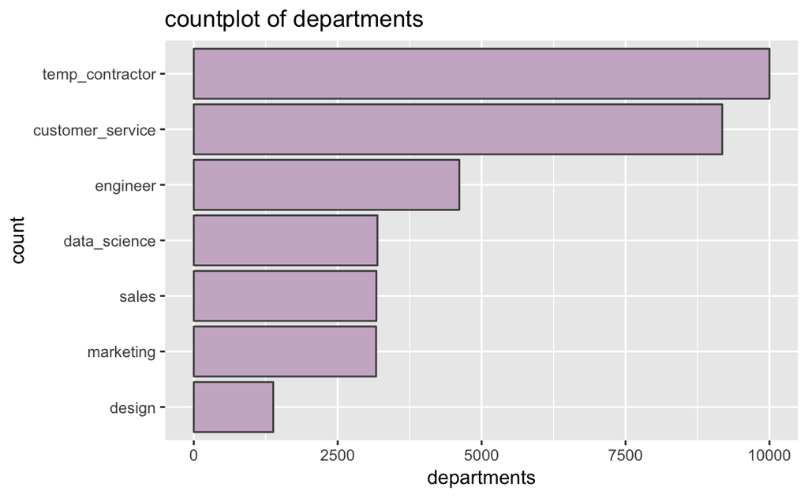

```r
data %>%
  group_by(dept) %>%
  tally %>%
  mutate(dept = fct_reorder(dept,n)) %>%
  ggplot(aes(x=dept,y=n,))+geom_bar(stat='identity',fill="thistle3",color="gray30", show.legend = FALSE)+coord_flip()+labs(x="count",y="departments",title="countplot of departments")
```

Most of the employees are temporary contracters and customer services.

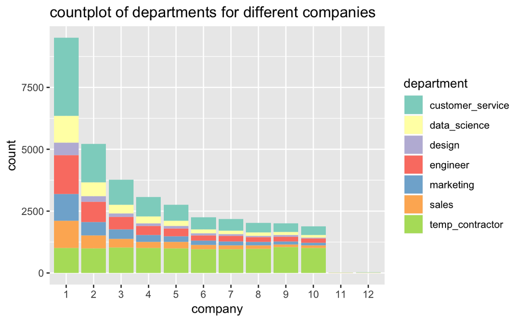

```r
# How many employees are in each company within each department
group <- data.frame(data %>% group_by(company_id,dept)%>%tally)
colnames(group) <- c("company_id","department","count")
ggplot(group, aes(x=as.factor(company_id), y=count, fill=department))+geom_bar(stat='identity')+labs(x="company",title="countplot of departments for different companies")+scale_fill_brewer(palette="Set3")
```

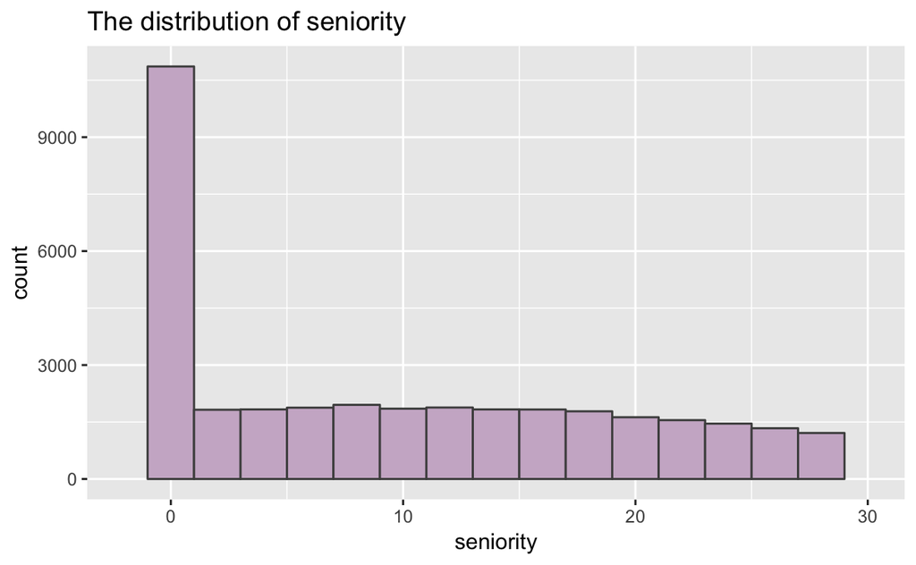

```r
#Senority distribution
data %>%
  ggplot(aes(x=seniority))+geom_histogram(fill="thistle3",color="gray30",binwidth=2,na.rm=TRUE,)+xlim(-2,30)+labs(title="The distribution of seniority")
```

Most of the employees are in senority 0.

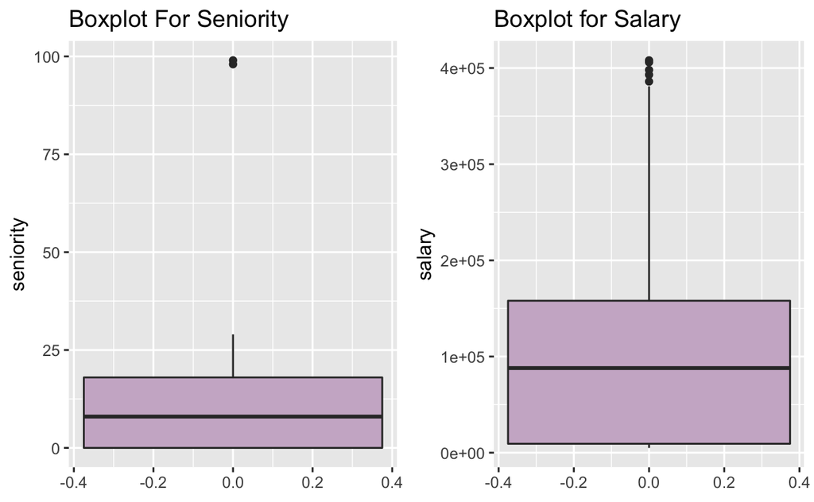

```r
#box plot for senority and salary
data  %>%
  ggplot(aes(y=seniority))+geom_boxplot(na.rm=TRUE,fill="thistle3")+labs(title="Boxplot For Seniority") -> a
data  %>%
  ggplot(aes(y=salary))+geom_boxplot(na.rm=TRUE,fill="thistle3")+labs(title="Boxplot for Salary") -> b
#Combine two plots
ggarrange(a,b,ncol=2, nrow=1,legend="bottom")
```

```r
print(paste0("The median seniority is " ,median(data$seniority,na.rm=TRUE)))
```

```
[1] "The median seniority is 8"
```

```r
print(paste0("The median salary is " , median(data$salary,na.rm=TRUE)))
```

```
[1] "The median salary is 88000"
```

There are some outliers for seniority and salary; The median seniority level is 8 and the median salary is 88000.

```r
#How many outliers in seniority?
data[data$seniority>80,]
```

```
      employee_id company_id      dept seniority salary  join_date  quit_date
23684       97289         10  engineer        98 266000 2011-12-13 2015-01-09
26544      604052          1 marketing        99 185000 2011-07-26 2013-12-06
      tenure week quit
23684   3.08    2    1
26544   2.37   49    1
```

```r
data = data[data$seniority<=80,]
```

Only two outliers for the seniorty, we can simply remove them.

```r
#How many outliers in salary?
length(data[data$salary>=350000,"dept"])
```

```
[1] 339
```

```r
unique(data$dept[which(data$salary>350000)])
```

```
[1] engineer     data_science
7 Levels: customer_service data_science design engineer marketing ... temp_contractor
```

There are 339 outliers for the salary, all of them come from department engineer , data science. This is resonable as some top engineers and data scientists could have such high salary, I will not remove them.

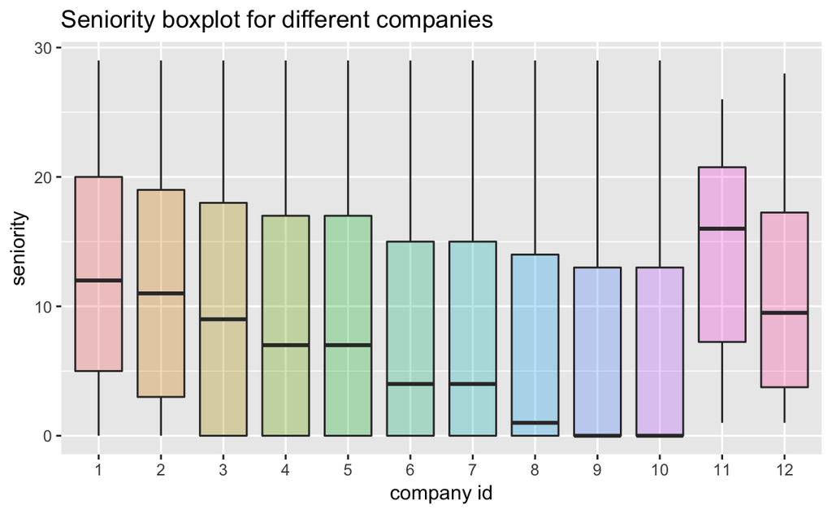

```r
#seniority for different companies and departments
data[,c("company_id","seniority")] %>%
  ggplot(aes( x=as.factor(company_id), y=seniority,fill=as.factor(company_id)))+geom_boxplot(alpha=0.3)+labs(title="Seniority boxplot for different companies",x="company id")+theme(legend.position="none")
```

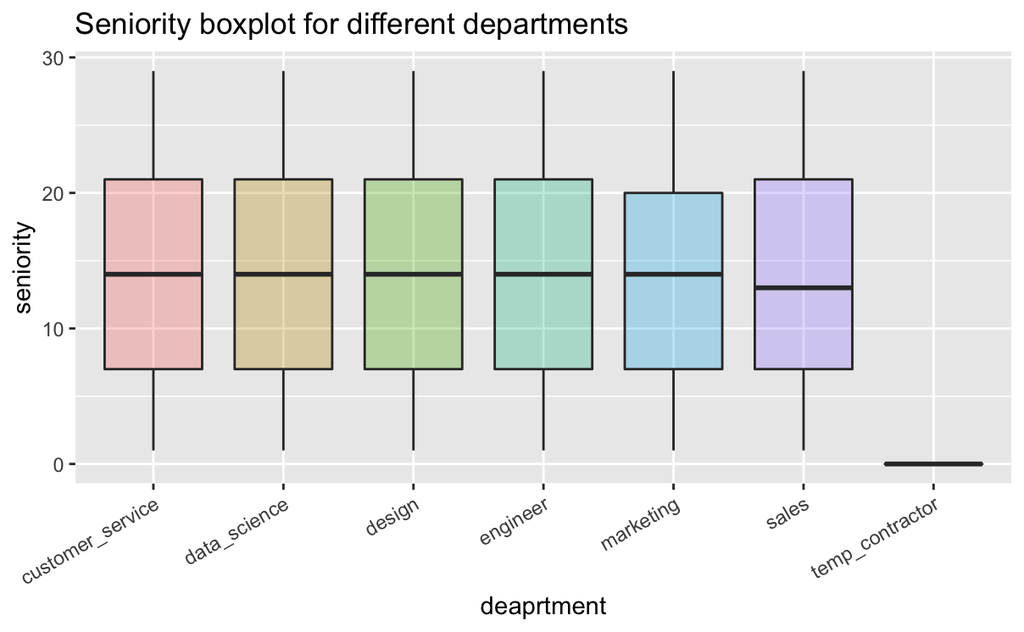

```r
data[,c("dept","seniority")] %>%
  ggplot(aes( x=as.factor(dept), y=seniority,fill=as.factor(dept)))+geom_boxplot(alpha=0.3)+labs(title="Seniority boxplot for different departments",x="deaprtment")+theme(legend.position ="none",axis.text.x = element_text(angle=30,hjust=1))
```

Generally, the employees from company 11 are in higher seniority than other companies. Although company 11 doesn’t have many employees, the majority of its employees are in high seniority, which indicates that company 11 may be a technology star-up; Among all the departments, temporary contracter has the lowest seniority, sales has the second lower seniority.

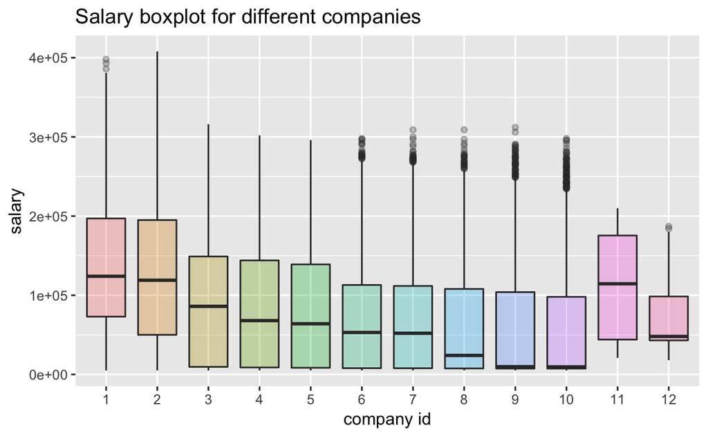

```r
#salary for different companies and departments
data[,c("company_id","salary")] %>%
  ggplot(aes( x=as.factor(company_id), y=salary,fill=as.factor(company_id)))+geom_boxplot(alpha=0.3,na.rm=TRUE)+labs(title="Salary boxplot for different companies",x="company id")+theme(legend.position = "none")
```

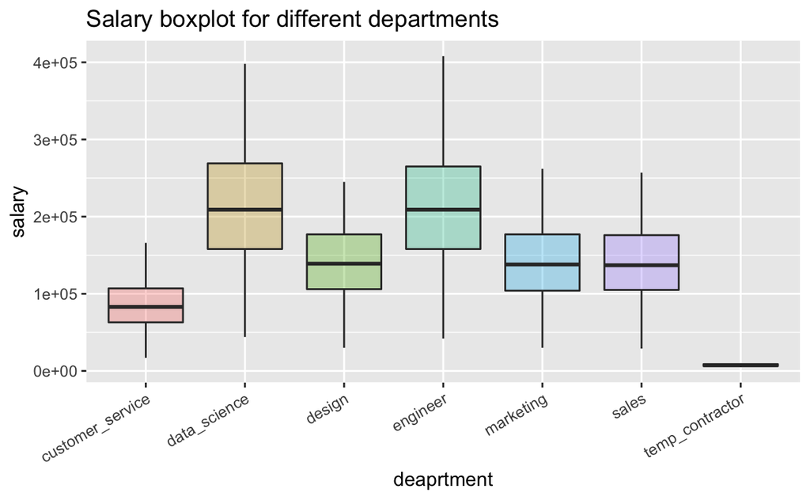

```r
data[,c("dept","salary")] %>%
  ggplot(aes( x=as.factor(dept), y=salary,fill=as.factor(dept)))+geom_boxplot(alpha=0.3,na.rm=TRUE)+labs(title="Salary boxplot for different departments",x="deaprtment")+theme(legend.position = "none", axis.text.x=element_text(angle=30, hjust=1))
```

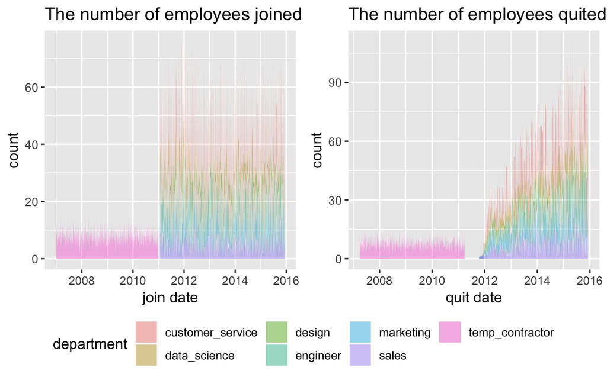

```r
#How do departments change with time?
data %>%
  group_by(join_date,dept) %>%
  tally %>%
  ggplot(aes(x=join_date,y=n,fill=dept))+geom_area(alpha=0.4,na.rm=TRUE)+labs(title="The number of employees joined")+ylab("count")+xlab("join date")+scale_fill_discrete(name = "department")+theme(legend.position="none") -> a
data %>%
  group_by(quit_date,dept) %>%
  tally %>%
  ggplot(aes(x=quit_date,y=n,fill=dept))+geom_area(alpha=0.4,na.rm=TRUE)+labs(title="The number of employees quited")+ylab("count")+xlab("quit date")+scale_fill_discrete(name = "department") -> b
#Combine two plots
ggarrange(a,b,common.legend=TRUE,legend="bottom")
```

Before 2011, all the companies only hired temporary contracters; after 2011, companies hired more empoyeees at a steady rate. In particular, the companies expanded mostly in marketing and customer service group, the temporary contracters group was largely shrinked. On the other side, more and more employees quited after 2011 at an increasing rate, the majority of them are also in marketing and customer service group.

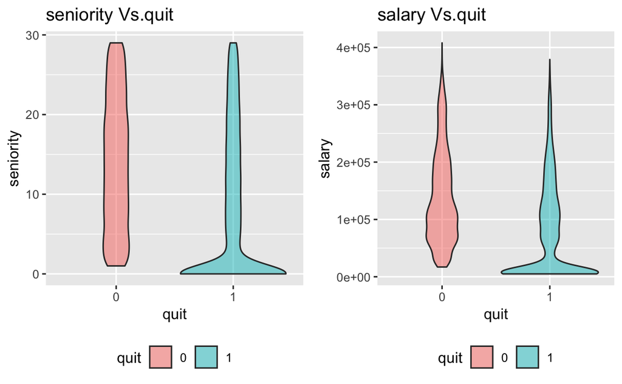

```r
#How do senority, salary and tenure affect the retention rate?
data %>%
  ggplot(aes(x=as.factor(quit),y=seniority,fill=as.factor(quit)))+geom_violin(alpha=0.5, na.rm=TRUE)+theme(legend.position="none")+xlab("quit")+labs(title="seniority Vs.quit")+scale_fill_discrete(name="quit") -> a
data %>%
  ggplot(aes(x=as.factor(quit),y=salary,fill=as.factor(quit)))+geom_violin(alpha=0.5, na.rm=TRUE)+theme(legend.position="none")+xlab("quit")+labs(title="salary Vs.quit")+scale_fill_discrete(name='quit') -> b
#Combine two plots
ggarrange(a,b,legend="bottom")
```

Most of employees who quit are in lower seniority(below 5) or have lower salary(below 50000), this is resonable as less experienced employees are more likely to seek for better job opportunities after they got some experience.

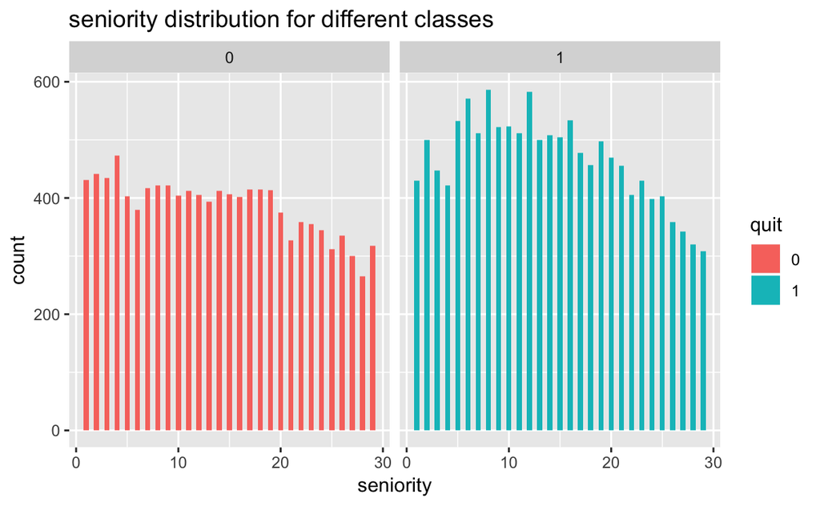

```r
data %>%
  filter(seniority!=0) %>%
  mutate(quit=as.factor(quit)) %>%
  ggplot(aes(seniority,fill=quit))+geom_histogram(bins=20,binwidth = 0.5)+facet_wrap(~quit)+labs(title="seniority distribution for different classes")
```

The distribution of seniority for group “quit=1” skews to the right, which corresponds to the previous result that most of the employees who quit have lower seniority.

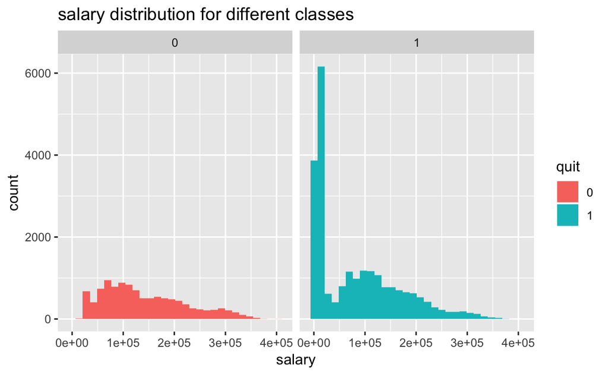

```r
data %>%
  filter(!is.na(salary)) %>%
  mutate(quit=as.factor(quit)) %>%
  ggplot(aes(x=salary,fill=quit))+geom_histogram(bins=30)+facet_wrap(~quit)+labs(title="salary distribution for different classes")
```

Again, most of the employees who quit are in lower and mid salary(less than 150000), as the employees with higher salary are always satisfied and won’t quit.

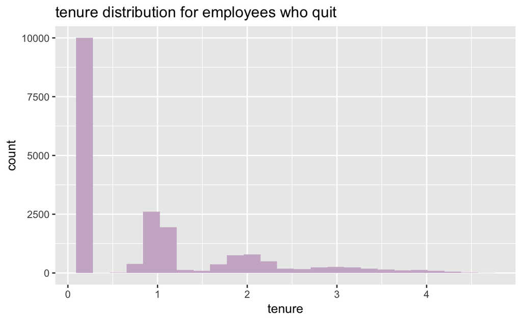

```r
#When do the most of employees quit?
data %>%
  filter(!is.na(tenure)) %>%
  ggplot(aes(x=tenure))+geom_histogram(bins=25,fill="thistle3")+labs(title="tenure distribution for employees who quit")
```

Most of the employees quit their jobs in three months and around one year anniversary, they may found the job isn’t suitable for them in three probation period or they may want to get the yearly bonus before they leave.

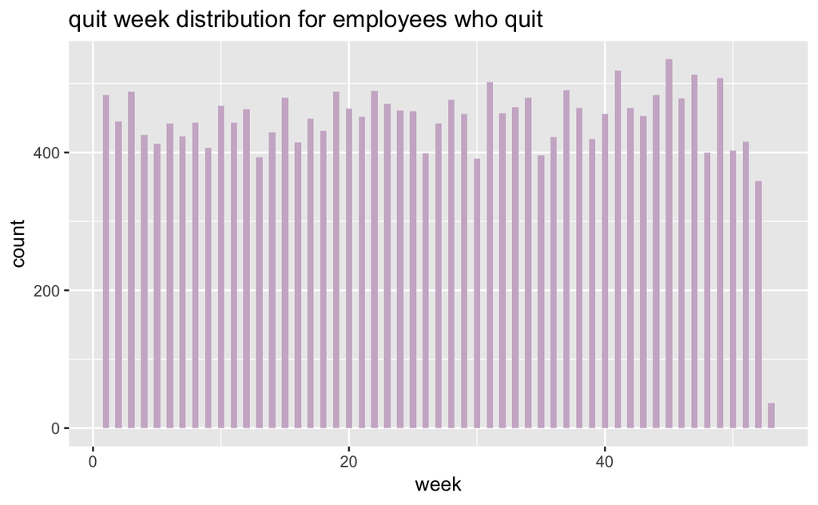

```r
#When do the most of employees quit?
data %>%
  filter(!is.na(week)) %>%
  ggplot(aes(x=week))+geom_histogram(bins=48,binwidth=0.5,fill="thistle3")+labs(title="quit week distribution for employees who quit")
```

Employees quit slightly more right before the end of the year (< 49th week) as well as at the beginning of the year (1st-3rd week), as they may want to get yearly bonus before they quit + there are more job opening at the beginning of the year.

# Data Imputation

Since I use “tenure” to represent the feature “join_date” and “quit_date”, I’ll simply drop these two columns along with column “employee_id”, which is clearly irrelavent to the classification result.

```r
#Deal with NAs
##Drop the "join_date", "quit_date" and "employee_id"
data <- data[-c(1,6,7)]
summary(data)
```

[output not shown]

Here, I want to impute the NAs in salary using K-nearest-neighbors

```r
#Create dummy variables
dummy1 = dummy(data$company_id,sep=".")
dummy2 = dummy(data$dept,sep=".")
data  = data.frame(data[3:7],dummy1,dummy2)
#Impute NAs in "salary"
index_na = which(is.na(data$salary))
train <- data[!is.na(data$salary),]
test <- data[is.na(data$salary),]
knn <- knn.reg(train=as.matrix(train[-c(2:4)]),test=test[-c(2:4)], y=train$salary,k=8,algorithm="kd_tree")
data$salary[index_na] = knn$pred
```

```r
#Impute NAs in "tenure"
index_na2 = which(is.na(data$tenure))
train <- data[!is.na(data$tenure),]
test <- data[is.na(data$tenure),]
knn2 <- knn.reg(train=as.matrix(train[-c(3:4)]),test=test[-c(3:4)], y=train$tenure,k=8,algorithm="kd_tree")
data$tenure[index_na2] <- knn2$pred
```

```r
prop <- table(data$quit)/dim(data)[1]
print(paste("The propotion of class 0 is ", round(prop[1]*100,2),"%", sep=""))
```

```
[1] "The propotion of class 0 is 32.25%"
```

```r
print(paste("The propotion of class 1 is ", round(prop[2]*100,2),"%", sep=""))
```

```
[1] "The propotion of class 1 is 67.75%"
```

The data is imbalanced, I’ll try up-sampling.

```r
#Up-sampling
index0 <- which(data$quit==0)
index1 <- which(data$quit==1)
diff <- length(index1)-length(index0)
index0 <- c(sample(index0, diff, replace=TRUE),index0)
data <- data[c(index0, index1),]
```

Split the dataset into training and testing

```r
#Train-Test-Split
data_cleaned <- data[-4]
prop = round(0.8*dim(data_cleaned)[1])
sample_index <- sample(1:dim(data_cleaned)[1],prop, replace=FALSE)
train <- data_cleaned[sample_index,]
test <- data_cleaned[-sample_index,]
```

Baseline: Logistic Regression Assumption Checking

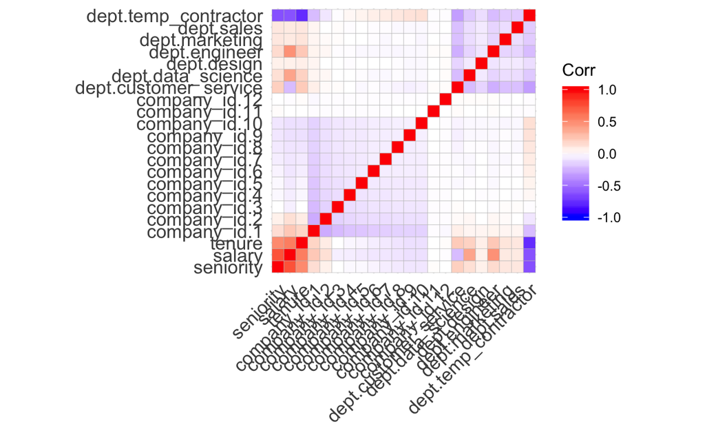

```r
#Check multi-colinearity
corrm <- cor(data_cleaned[-4])
ggcorrplot(corrm)
```

```r
print(paste("There are ",sum(abs(corrm)>0.8)-dim(corrm)[1]," predictor pairs that have correlation greater than 0.8"))
```

```
[1] "There are  0  predictor pairs that have correlation greater than 0.8"
```

There is no multi-colinearity.

```r
g <- glm(quit~.,family=binomial,data=train)
```

```
glm.fit: algorithm did not converge
```

```r
predictions1 <- predict(g, newdata=test[-4],type='response')
```

```
prediction from a rank-deficient fit may be misleading
```

```r
print(paste("The accuracy for logistic regression is ", round(mean(ifelse(predictions1>0.5,1,0)==test$quit)*100,2),"%",sep=""))
```

```
[1] "The accuracy for logistic regression is 71.35%"
```

The accuracy for logistic regression is 71.35%

```r
summary(g)
```

```
Call:
glm(formula = quit ~ ., family = binomial, data = train)

Deviance Residuals:
    Min       1Q   Median       3Q      Max
-1.6970  -0.9585   0.0000   1.3572   1.7091

Coefficients: (1 not defined because of singularities)
                        Estimate Std. Error z value Pr(>|z|)
(Intercept)            2.252e+11  1.258e+12   0.179 0.857955
seniority              7.972e-03  2.697e-03   2.956 0.003121 **
salary                -1.544e-06  4.257e-07  -3.626 0.000288 ***
tenure                -8.551e-02  2.286e-02  -3.740 0.000184 ***
company_id.1           2.189e-01  4.106e-01   0.533 0.593982
company_id.2           1.344e-01  4.113e-01   0.327 0.743895
company_id.3           2.321e-01  4.111e-01   0.565 0.572332
company_id.4           2.458e-01  4.117e-01   0.597 0.550408
company_id.5           2.148e-01  4.121e-01   0.521 0.602232
company_id.6           1.700e-01  4.130e-01   0.412 0.680616
company_id.7           3.003e-01  4.131e-01   0.727 0.467187
company_id.8           2.044e-01  4.137e-01   0.494 0.621260
company_id.9           2.338e-01  4.142e-01   0.564 0.572463
company_id.10          2.844e-01  4.146e-01   0.686 0.492810
company_id.11          1.799e+00  7.075e-01   2.544 0.010974 *
company_id.12                 NA         NA      NA       NA
dept.customer_service -2.252e+11  1.258e+12  -0.179 0.857955
dept.data_science     -2.252e+11  1.258e+12  -0.179 0.857955
dept.design           -2.252e+11  1.258e+12  -0.179 0.857955
dept.engineer         -2.252e+11  1.258e+12  -0.179 0.857955
dept.marketing        -2.252e+11  1.258e+12  -0.179 0.857955
dept.sales            -2.252e+11  1.258e+12  -0.179 0.857955
dept.temp_contractor  -2.252e+11  1.258e+12  -0.179 0.857955
---
Signif. codes:  0 ‘***’ 0.001 ‘**’ 0.01 ‘*’ 0.05 ‘.’ 0.1 ‘ ’ 1

(Dispersion parameter for binomial family taken to be 1)

    Null deviance: 52143  on 37612  degrees of freedom
Residual deviance: 38759  on 37591  degrees of freedom
AIC: 38803

Number of Fisher Scoring iterations: 25
```

```r
names(g$coefficients)[order(abs(g$coefficients),decreasing=TRUE)]
```

```
 [1] "dept.customer_service" "dept.engineer"         "dept.design"
 [4] "dept.data_science"     "dept.sales"            "dept.marketing"
 [7] "(Intercept)"           "dept.temp_contractor"  "company_id.11"
[10] "company_id.7"          "company_id.10"         "company_id.4"
[13] "company_id.9"          "company_id.3"          "company_id.1"
[16] "company_id.5"          "company_id.8"          "company_id.6"
[19] "company_id.2"          "tenure"                "seniority"
[22] "salary"                "company_id.12"
```

“Seniority”, “Salary” and “Tenure” have relationship with the retention result, and the effect is ranked by “Tenure” > “Seniority” > “Salary”. The employees with higher tenure and salary are less likely to leave the country.

Advanced Model-Random Forest

```r
#tuning "ntree"
tree_num <- c(10,50,100,300,500,800,1000,1500,2000)
OOB_error <- c()
for(i in tree_num){
  rf <- randomForest(as.factor(quit)~.,data=train,importance=TRUE,ntree=i)
  OOB_error <- c(OOB_error, rf$err.rate[i,1])

}
print(OOB_error)
```

```
      OOB       OOB       OOB       OOB       OOB       OOB       OOB       OOB       OOB
0.1779049 0.1647303 0.1630553 0.1636136 0.1632680 0.1632946 0.1632414 0.1630287 0.1631883
```

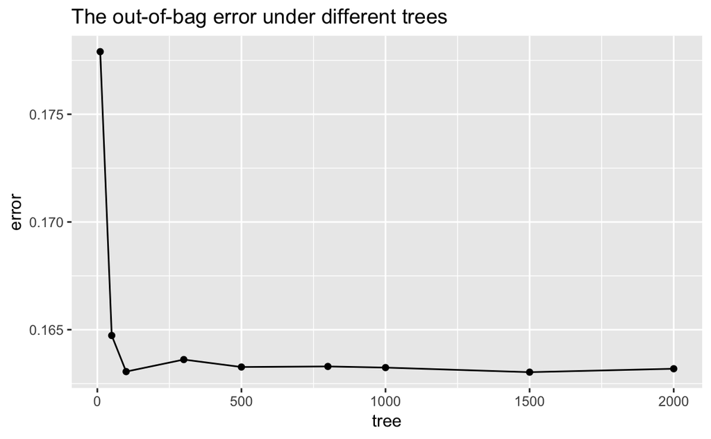

```r
#Plot for out-of-bag error
error <- data.frame(tree=tree_num,error=OOB_error)
ggplot(error, aes(x=tree, y=error))+geom_line()+geom_point()+labs(title="The out-of-bag error under different trees")
```

We choose ntree = 1500, at which the out-of-bag error is at minimum.

```
invalid mtry: reset to within valid range
```

```
mtry = 24  OOB error = 11.61%
Searching left ...
mtry = 20   OOB error = 11.59%
0.001831921 0.05
Searching right ...
mtry = 22   OOB error = 11.57%
0.003205862 0.05
```

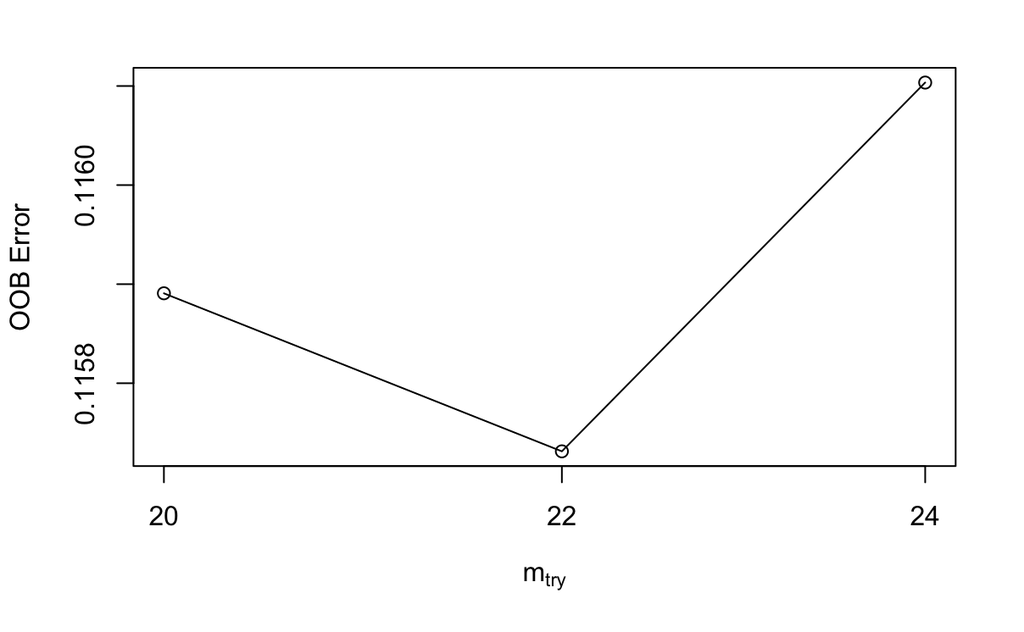

```r
#tuning "mtry"
mt <- tuneRF(train[-4],as.factor(train$quit),ntreeTry=1500,mtryStart = 24, stepFactor=1.2, doBest = T)
```

```r
mt$mtry
```

```
[1] 22
```

The minimum OOB error occurs at mtry=22.

```r
rf <- randomForest(as.factor(quit)~.,train,importance=TRUE,ntree=1500,xtest=test[-4],ytest=as.factor(test$quit),mtry=22)
```

```r
predictions2 <- (rf$test)$predicted
print(paste("The accuracy for random forest is ", round(mean(predictions2==test$quit)*100,2),"%",sep=""))
```

```
[1] "The accuracy for random forest is 89.1%"
```

```r
index_order <- order(importance(rf,type=2),decreasing=TRUE)
importance(rf,type=2)[index_order,]
```

```
               tenure                salary             seniority
         12398.135999           2093.599731           1446.257990
         company_id.1          company_id.2          company_id.3
           211.030704            177.530478            163.470525
         company_id.4        dept.marketing            dept.sales
           144.617497            139.962767            139.920126
         company_id.5         dept.engineer     dept.data_science
           132.608104            120.942356            119.591332
         company_id.7          company_id.6          company_id.8
           114.946064            112.736408            108.273998
          dept.design          company_id.9         company_id.10
           102.160185            101.009764             88.768614
dept.customer_service         company_id.11         company_id.12
            71.863068              4.878406              2.549204
 dept.temp_contractor
             0.000000
```

The top three important predictors are “tenure”,“salary” and “seniority”, this corresponds to what we get from logistic regression.

```r
pred <- prediction(rf$test$votes[,2],test$quit)
perf <- performance(pred,'tpr','fpr')
performance(pred,"auc")#auc=0.95
```

```
An object of class "performance"
Slot "x.name":
[1] "None"

Slot "y.name":
[1] "Area under the ROC curve"

Slot "alpha.name":
[1] "none"

Slot "x.values":
list()

Slot "y.values":
[[1]]
[1] 0.9468499


Slot "alpha.values":
list()
```

## Task 2 - Main factors that drive employee churn.

The top three important factors are “tenure”, “salary” and “seniority” ; The employees with lower or mid “salary” are more likely to quit their job, as they may want to seek for jobs with better pay, while employees with higher salary are always satisfied with their pay. Employees with lower “tenure” are also likely to quit their job, as many employees may quit thier job in probation period, where they find the job not suitable for them or they may just want to gather some experience and then seek for a better opportunity.

## Task 3 - Features that could be added.

—-Promotion(0 or 1), which is cheap to get from HR tracking system; —-Projects finished during the tenure, which is cheap to get from HR tracking system; —-Percent of salary increased —-Personal Assessment of the company —-Company bonus information